# Homework - Week 6

# Exercice 2

## Question

Revisit the Reedfrog survival data, data(reedfrogs). Start with the varying effects model from the book and lecture. Then modify it to estimate the causal effects of the treatment variables pred and size, including how size might modify the effect of predation. An easy approach is to estimate an effect for each combination of pred and size. Justify your model with a DAG of this experiment.

## Answer

#### Modeling

$$\begin{aligned}
Sur_i \sim \text{Binomial}(D_i, p_i)\\
\text{logit}(p_i) = \bar{\alpha} + z_{\alpha,T_i}\sigma_\alpha + z_{\beta,P_i,S_i}\sigma_\beta\\
\bar{\alpha} \sim \text{Normal}(0,1.5)\\
z_{\alpha,j} \sim \text{Normal}(0,1)\\
z_{\beta,j} \sim \text{Normal}(0,1)\\
\sigma_\alpha,\sigma_\beta \sim \text{Exponential}(1)
\end{aligned}$$

```r
precis(m2, pars = c("a_bar", "sA", "sB"))
```

|  | mean | sd | 5.5% | 94.5% | n_eff | Rhat4 |
| --- | --- | --- | --- | --- | --- | --- |
| a_bar | 0.97 | 0.76 | -0.30 | 2.09 | 586 | 1.01 |
| sA | 0.75 | 0.14 | 0.54 | 0.99 | 819 | 1.00 |
| sB | 1.66 | 0.64 | 0.92 | 2.86 | 1017 | 1.00 |

```r
plot(precis(m2, pars = c("a_bar", "sA", "sB")))
```

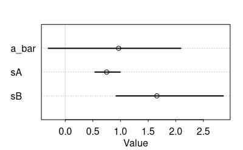

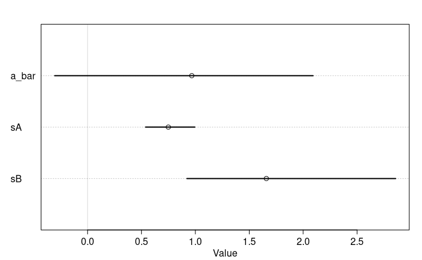

#### Model investigation

```r
post.samples <- extract.samples(m2)
```

##### Survival rate across the population of tanks

```r
abar <- inv_logit(post.samples$a_bar)
abar.hpdi <- HPDI(abar)
abar.dens <- with(density(abar), tibble(x,y))

abar.dens %>%
    ggplot(aes(x, y)) +
    geom_line(color=2) +
    geom_area(data=subset(abar.dens, x > abar.hpdi[1] & x < abar.hpdi[2]), fill=2, alpha=0.4) +
    geom_rug(aes(x=propsurv, y=0), data=d, sides="b", color=2, size=2, alpha=0.4) +
    ylab('Density') +
    xlab("posterior distribution of the survival rate across the tanks' population")
```

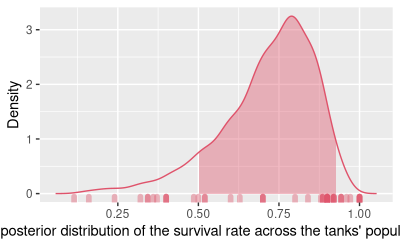

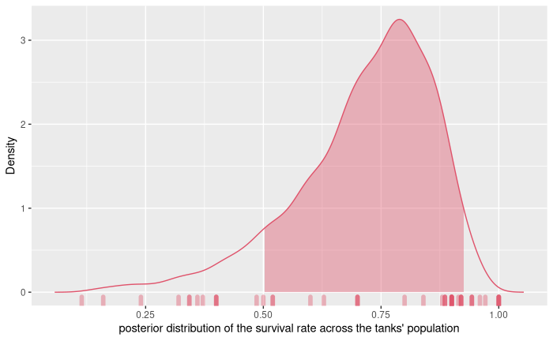

##### Direct effect of `T`ank

```r
alpha <- inv_logit(post.samples$a)

alpha.df <- tibble(tank = c(1:48))

alpha.df$mean <- apply(alpha,2,mean)
alpha.df$lhpdi <- apply(alpha,2,HPDI)[1,]
alpha.df$hhpdi <- apply(alpha,2,HPDI)[2,]

alpha.df %>%
    ggplot() +
    geom_pointrange(aes(x=tank, y =mean, ymin=lhpdi, ymax=hhpdi), color=2) +
    geom_point(aes(x=tank, y=propsurv), data=d) +
    geom_hline(yintercept = mean(d$propsurv), ) +
    geom_vline(xintercept = c(max(d[d$density==10,]$tank) + 0.5,
                              max(d[d$density==25,]$tank) + 0.5,
                              max(d[d$density==35,]$tank) + 0.5)) +
    ylab("survival probability")
```

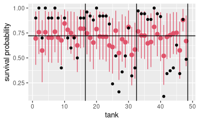

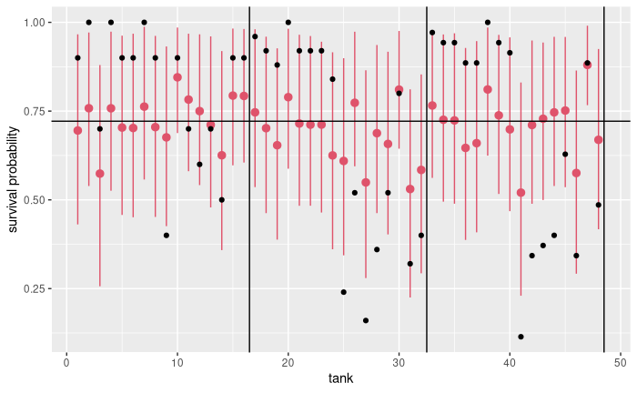

##### Combined direct effect of predation and size

```r
beta <- inv_logit(post.samples$b)
dimnames(beta)[[2]] <- c('no', 'pred')
dimnames(beta)[[3]] <- c('small', 'big')

beta.hpdi <- apply(beta, c(2,3), HPDI)
beta.hpdi %>%
    as_tibble() %>%
    tibble::add_column(HPDI = c("|0.89", "0.89|"), .before = 'no.small')
```

| HPDI | no.small | pred.small | no.big | pred.big |
| --- | --- | --- | --- | --- |
| \|0.89 | 0.6285088 | 0.1266798 | 0.6582297 | 0.04205307 |
| 0.89\| | 0.9742828 | 0.6413506 | 0.9757770 | 0.40026766 |

```r
lhpdi <- c(beta.hpdi[1,1,],beta.hpdi[1,2,])
hhpdi <- c(beta.hpdi[2,1,],beta.hpdi[2,2,])
names(lhpdi) <- c("no.small", "no.big", "pred.small", "pred.big")
names(hhpdi) <- c("no.small", "no.big", "pred.small", "pred.big")

beta.df <- as_tibble(beta) %>% pivot_longer(everything()) %>%
    group_by(name) %>%
    group_modify(~ with(density(.x$value), tibble(x,y))) %>%
    mutate(lhpdi = flatten_dbl(map(name, ~ lhpdi[.x])),
           hhpdi = flatten_dbl(map(name, ~ hhpdi[.x])))

beta.df %>% ggplot(aes(x=x, y=y, color=name, fill=name)) +
    geom_line() +
    geom_area(data=subset(beta.df, x > lhpdi & x < hhpdi), alpha = 0.2) +
    geom_rug(aes(x=propsurv, y=0, color=treatment), data=d, sides="b", size=2, alpha=0.4) +
    scale_color_discrete("PRED.SIZE") +
    scale_fill_discrete("PRED.SIZE") +
    ylab('Density') +
    xlab("posterior distribution β_j (probability)")
```

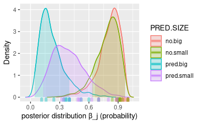

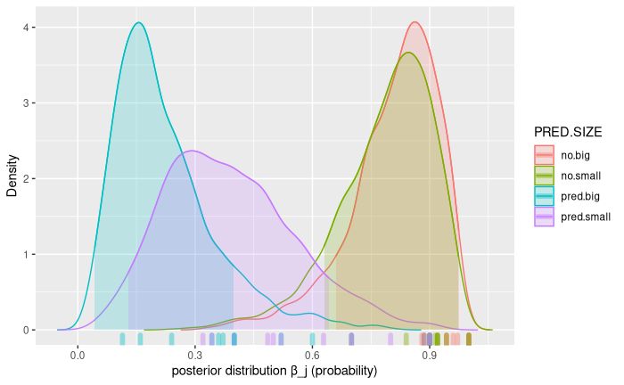

```r
p <- (link(m2))

p.df <- tibble(tank = c(1:48))

p.df$mean <- apply(p,2,mean)
p.df$lhpdi <- apply(p,2,HPDI)[1,]
p.df$hhpdi <- apply(p,2,HPDI)[2,]
p.df$pred <- d$pred

p.df %>%
    ggplot() +
    geom_pointrange(aes(x=tank, y=mean, ymin=lhpdi, ymax=hhpdi, color=pred)) +
    geom_point(aes(x=tank, y=propsurv, size=density), data=d) +
    geom_hline(yintercept = mean(d$propsurv)) +
    geom_vline(xintercept = c(max(d[d$density==10,]$tank) + 0.5,
                              max(d[d$density==25,]$tank) + 0.5,
                              max(d[d$density==35,]$tank) + 0.5)) +
    scale_size("Density", breaks = c(10,25,35), range = c(.5,2)) +
    scale_color_discrete("Predation") +
    ylab("survival probability")
```

[output not shown]

#### DAG

As the data comes from an experiment, it is reasonable to assume that there is no causal relationship between the controlled variables. `T`, `S` and `P` are competing causes, so they might be used in the same model to increase precision.

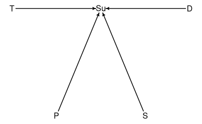

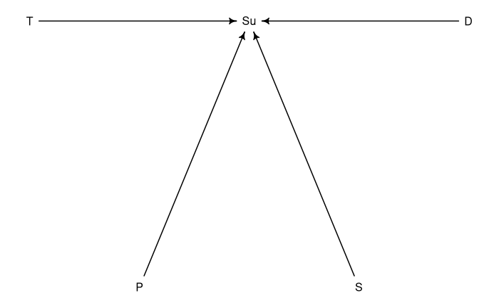

# Exercice 3

## Question

Now estimate the causal effect of density on survival. Consider whether pred modifies the effect of density. There are several good ways to include density in your Binomial GLM. You could treat it as a continuous regression variable (possibly standardized). Or you could convert it to an ordered category (with three levels). Compare the σ (tank standard deviation) posterior distribution to σ from your model in Problem 2. How are they different? Why?

## Answer

### Adapting the data

```r
dat$did <- ifelse(d$density == 10, 1, ifelse(d$density == 25, 2, 3))
dat$stdD <- standardize(dat$D)
```

### Modeling

$$\begin{aligned}
Sur_i \sim \text{Binomial}(D_i, p_i)\\
\text{logit}(p_i) = \bar{\alpha} + z_{\alpha,T_i}\sigma_\alpha + z_{\beta,P_i,S_i}\sigma_\beta + z_{\gamma,P_i}\sigma_\gamma * z_{D_i}\\
\bar{\alpha} \sim \text{Normal}(0,1.5)\\
z_{\alpha,j}, z_{\beta,j}, z_{\gamma,j} \sim \text{Normal}(0,1)\\
\sigma_\alpha,\sigma_\beta \sim \text{Exponential}(1)\\
\sigma_\gamma \sim \text{Exponential}(5)
\end{aligned}$$

```r
precis(m3, pars = c("a_bar", "sA", "sB", "sG", "g", "b"), depth = 3)
```

|  | mean | sd | 5.5% | 94.5% | n_eff | Rhat4 |
| --- | --- | --- | --- | --- | --- | --- |
| a_bar | 1.04 | 0.77 | -0.23 | 2.21 | 633 | 1 |
| sA | 0.69 | 0.14 | 0.48 | 0.93 | 859 | 1 |
| sB | 1.62 | 0.62 | 0.88 | 2.78 | 883 | 1 |
| sG | 0.26 | 0.17 | 0.03 | 0.57 | 1109 | 1 |
| g[1] | 0.06 | 0.17 | -0.19 | 0.36 | 1845 | 1 |
| g[2] | -0.27 | 0.19 | -0.57 | 0.00 | 582 | 1 |
| b[1,1] | 1.47 | 0.80 | 0.28 | 2.84 | 687 | 1 |
| b[1,2] | 1.63 | 0.81 | 0.41 | 3.00 | 659 | 1 |
| b[2,1] | -0.50 | 0.78 | -1.68 | 0.77 | 649 | 1 |
| b[2,2] | -1.40 | 0.78 | -2.58 | -0.13 | 675 | 1 |

```r
plot(precis(m3, pars = c("a_bar", "sA", "sB", "sG", "g", "b"), depth = 3))
```

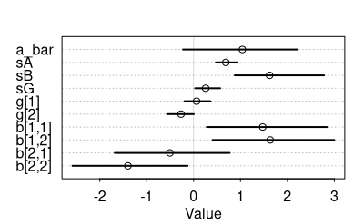

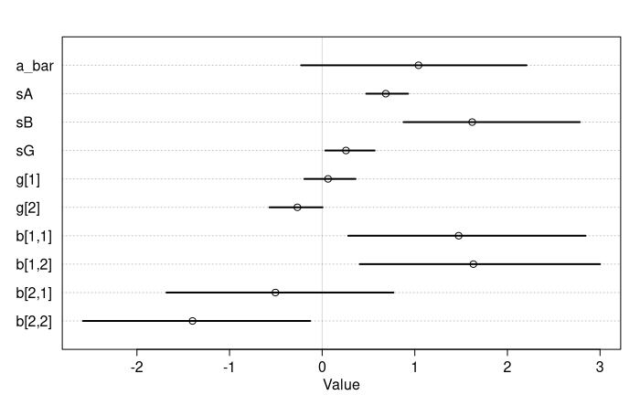

### Comparing σ_α

The difference between $\sigma_\alpha^1$, $\sigma_\alpha^2$, and $\sigma_\alpha^3$ is due to the fact that the variables added to the model are causes for the variation of the survival rate. Predation alone has a strong effect, dissolving a good deal of the variation spread across the tanks. Size, on other hand, lowers the variation in the cases where Predation is also seen, lowering the survival rates if predators find big tadpoles. This is the reason for the drop from $\sigma_\alpha^1$ to $\sigma_\alpha^2$. Also, as density is a cause for survival (tough small), particularly in presence of predators, its addition in the model causes part of the variation previously spread by the tanks variable to dissolve.

```r
s1 <- (extract.samples(m1)$sA)
s2 <- (extract.samples(m2)$sA)
s3 <- (extract.samples(m3)$sA)

sigmas <- tibble(model1=s1, model2=s2, model3=s3)
precis(sigmas)
```

```
'data.frame': 2000 obs. of 3 variables:
```

|  | mean | sd | 5.5% | 94.5% | histogram |
| --- | --- | --- | --- | --- | --- |
| model1 | 1.64 | 0.23 | 1.31 | 2.02 | ▁▂▇▇▃▁▁▁▁ |
| model2 | 0.75 | 0.14 | 0.54 | 0.99 | ▁▃▇▇▅▂▁▁▁▁ |
| model3 | 0.69 | 0.14 | 0.48 | 0.93 | ▁▁▂▅▇▇▃▂▁▁▁ |

```r
sigmas %>%
    pivot_longer(everything()) %>%
    ggplot(aes(x=value, color=name)) +
    geom_density(size=3) +
    scale_color_viridis_d("Model")
```

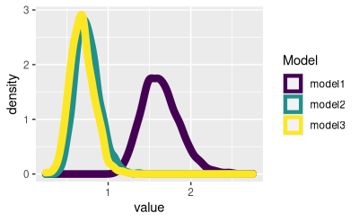

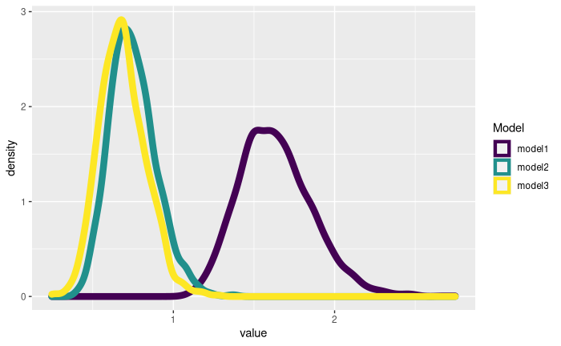

```r
s1 <- (extract.samples(m1)$sB)
s2 <- (extract.samples(m2)$sB)

sigmas <- tibble(model2=s2, model3=s3)
precis(sigmas)
```

```
'data.frame': 2000 obs. of 2 variables:
```

[output not shown]

```r
sigmas %>%
    pivot_longer(everything()) %>%
    ggplot(aes(x=value, color=name)) +
    geom_density(size=3) +
    scale_color_viridis_d("Model")
```

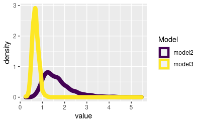

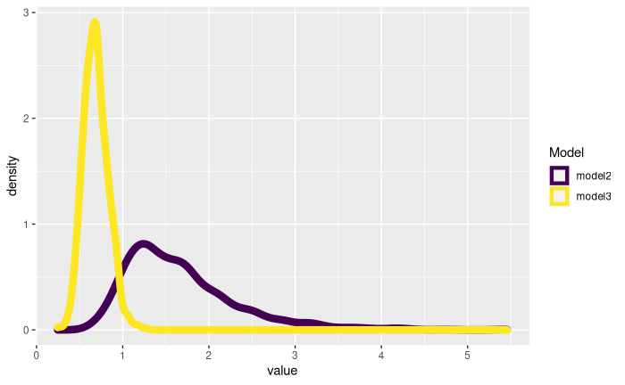